# PROGRA_TRABAJO

LAYMITO

9/7/2021

# 6 Ejercicios

### 6.1 Parte 1

### 1. Calcular los valores nuemricos

```r
a <- (0.3*0.15)/((0.3*0.15)+(0.2*0.8)+(0.5*0.12))
a
```

```
## [1] 0.1698113
```

```r
b <- ((5^6)/factorial(4))*exp(-5)
  b
```

```
## [1] 4.386684
```

```r
m <- matrix(c(20,7))
c <- m*((0.4)^7)*((0.6)^13)
c
```

```
##              [,1]
## [1,] 4.279728e-05
## [2,] 1.497905e-05
```

### 2. Realizar la siguiente suma

```r
a <- sum(1:1000)
a
```

```
## [1] 500500
```

```r
x <- 0:10
b <- sum(2^x)
b
```

```
## [1] 2047
```

### 3. El vector “grupo” representa una serie de alumnos

A. Cuantos elementos tiene?

```r
load("C:/Users/KEVIN/Downloads/datos.RData")
alum <- grupo
alum
```

```
##   [1] "B" "A" "E" "D" "B" "D" "D" "A" "D" "C" "D" "E" "B" "E" "E" "E" "A" "B"
##  [19] "C" "C" "A" "C" "C" "D" "D" "E" "E" "A" "B" "C" "C" "E" "D" "C" "E" "E"
##  [37] "E" "E" "D" "D" "D" "E" "E" "E" "D" "E" "B" "E" "D" "C" "E" "D" "E" "E"
##  [55] "C" "B" "D" "C" "E" "D" "E" "B" "D" "B" "B" "C" "D" "C" "C" "C" "E" "D"
##  [73] "E" "D" "C" "D" "E" "E" "C" "D" "C" "E" "D" "A" "B" "B" "E" "E" "C" "D"
##  [91] "C" "E" "E" "C" "E" "D" "D" "D" "E" "D" "A" "D" "B" "B" "C" "D" "E" "A"
## [109] "E" "E" "A" "C" "E" "D" "A" "D" "D" "C" "E" "E" "E" "D" "A" "E" "E" "E"
## [127] "C" "C" "B" "C" "C" "D" "C" "B" "C" "A" "D" "E" "D" "E" "E" "B" "E" "E"
## [145] "E" "E" "C" "B" "D" "D" "E" "E" "D" "D" "E" "D" "E" "D" "D" "C" "D" "D"
## [163] "D" "C" "E" "D" "E" "C" "E" "B" "C" "C" "C" "D" "D" "B" "D" "B" "E" "C"
## [181] "E" "D" "D" "E" "D" "B" "B" "E" "E" "A" "C" "A"
```

El vector “grupo” tiene:

```r
a <- length(alum)
a
```

```
## [1] 192
```

B. En que posicion del vector esta la letra “A”

```r
alum_A <- data.frame( ord = 1:192, alum)
head(alum_A)
```

```
##   ord alum
## 1   1    B
## 2   2    A
## 3   3    E
## 4   4    D
## 5   5    B
## 6   6    D
```

La letra “A” esta en la position :

```r
b <- alum_A[alum_A$alum == "A",]
b
```

```
##     ord alum
## 2     2    A
## 8     8    A
## 17   17    A
## 21   21    A
## 28   28    A
## 84   84    A
## 101 101    A
## 108 108    A
## 111 111    A
## 115 115    A
## 123 123    A
## 136 136    A
## 190 190    A
## 192 192    A
```

### 4. El vector “nota” representa la nota de un examen de alumnos del vector “grupo”

A. Cuanto suma todas las notas?

```r
not <- nota
a <- sum(not)
a
```

```
## [1] 962
```

B. Cual es la media aritmética de todas las notas?

```r
b <- mean(not)
b
```

```
## [1] 5.010417
```

C. ¿En qué posiciones están las notas mayores de 7.0?

La posicion de las notas mayores a 7 son :

```r
length(not)
```

```
## [1] 192
```

```r
c <- data.frame( orden = 1:192, not)
nota7 <- c[c$not > 7,]
nota7
```

```
##     orden not
## 81     81 7.2
## 103   103 7.4
## 120   120 7.7
## 151   151 7.5
```

```r
sort(not)
```

```
##   [1] 1.7 2.5 2.6 2.7 2.9 2.9 2.9 3.0 3.1 3.2 3.2 3.2 3.4 3.4 3.4 3.4 3.5 3.6
##  [19] 3.6 3.6 3.7 3.7 3.7 3.7 3.8 3.8 3.8 3.9 3.9 4.0 4.0 4.0 4.0 4.0 4.0 4.1
##  [37] 4.1 4.1 4.1 4.1 4.2 4.2 4.2 4.2 4.2 4.2 4.2 4.2 4.3 4.3 4.3 4.4 4.4 4.4
##  [55] 4.4 4.4 4.4 4.4 4.5 4.5 4.5 4.5 4.5 4.5 4.6 4.6 4.6 4.6 4.7 4.7 4.7 4.7
##  [73] 4.7 4.7 4.7 4.7 4.7 4.7 4.8 4.8 4.8 4.8 4.8 4.8 4.9 4.9 4.9 4.9 4.9 4.9
##  [91] 5.0 5.0 5.0 5.0 5.0 5.0 5.0 5.0 5.0 5.1 5.2 5.2 5.2 5.2 5.2 5.2 5.2 5.3
## [109] 5.3 5.3 5.3 5.4 5.4 5.4 5.4 5.4 5.4 5.4 5.4 5.5 5.5 5.5 5.5 5.5 5.5 5.5
## [127] 5.5 5.5 5.5 5.5 5.5 5.5 5.6 5.6 5.6 5.6 5.6 5.6 5.7 5.7 5.7 5.7 5.7 5.8
## [145] 5.8 5.8 5.8 5.8 5.9 5.9 5.9 5.9 5.9 5.9 5.9 5.9 5.9 6.0 6.0 6.0 6.0 6.0
## [163] 6.0 6.1 6.1 6.1 6.1 6.2 6.2 6.2 6.2 6.2 6.2 6.3 6.4 6.4 6.4 6.4 6.5 6.6
## [181] 6.8 6.8 6.8 6.8 6.8 6.9 6.9 7.0 7.2 7.4 7.5 7.7
```

E. En qué posición está la nota máxima?

```r
e <- c[c$not == max(not),]
e
```

```
##     orden not
## 120   120 7.7
```

### 5. A partir de los vectores “grupo” y “nota” definidos.

A. Suma las notas de los 10 primeros alumnos del vector

```r
grupo
```

```
##   [1] "B" "A" "E" "D" "B" "D" "D" "A" "D" "C" "D" "E" "B" "E" "E" "E" "A" "B"
##  [19] "C" "C" "A" "C" "C" "D" "D" "E" "E" "A" "B" "C" "C" "E" "D" "C" "E" "E"
##  [37] "E" "E" "D" "D" "D" "E" "E" "E" "D" "E" "B" "E" "D" "C" "E" "D" "E" "E"
##  [55] "C" "B" "D" "C" "E" "D" "E" "B" "D" "B" "B" "C" "D" "C" "C" "C" "E" "D"
##  [73] "E" "D" "C" "D" "E" "E" "C" "D" "C" "E" "D" "A" "B" "B" "E" "E" "C" "D"
##  [91] "C" "E" "E" "C" "E" "D" "D" "D" "E" "D" "A" "D" "B" "B" "C" "D" "E" "A"
## [109] "E" "E" "A" "C" "E" "D" "A" "D" "D" "C" "E" "E" "E" "D" "A" "E" "E" "E"
## [127] "C" "C" "B" "C" "C" "D" "C" "B" "C" "A" "D" "E" "D" "E" "E" "B" "E" "E"
## [145] "E" "E" "C" "B" "D" "D" "E" "E" "D" "D" "E" "D" "E" "D" "D" "C" "D" "D"
## [163] "D" "C" "E" "D" "E" "C" "E" "B" "C" "C" "C" "D" "D" "B" "D" "B" "E" "C"
## [181] "E" "D" "D" "E" "D" "B" "B" "E" "E" "A" "C" "A"
```

```r
nota
```

```
##   [1] 4.9 5.4 5.2 6.8 5.0 6.2 4.4 4.1 4.3 5.5 5.5 4.8 6.4 6.8 5.5 4.7 5.2 6.4
##  [19] 4.8 3.4 4.7 6.0 5.9 5.4 5.3 5.6 6.9 5.6 4.2 4.4 5.8 4.8 6.1 6.2 6.6 5.2
##  [37] 4.6 5.0 2.5 4.0 5.6 4.9 5.4 3.9 4.2 4.7 4.2 5.4 3.7 6.2 5.9 3.7 5.8 2.7
##  [55] 5.6 5.0 2.6 5.0 4.9 3.4 5.9 4.3 6.1 4.5 5.5 3.2 3.2 6.4 4.4 6.0 5.0 5.4
##  [73] 7.0 3.8 4.2 4.7 4.7 5.3 6.8 4.0 7.2 4.8 6.0 4.1 4.5 5.8 2.9 5.0 4.6 4.9
##  [91] 6.8 4.2 6.9 5.7 5.7 6.4 4.4 4.2 4.5 5.8 4.3 3.7 7.4 3.9 5.2 4.9 3.6 5.5
## [109] 6.0 5.0 4.1 4.5 3.1 5.4 4.5 5.3 4.7 6.1 5.2 7.7 5.3 5.0 4.0 5.2 4.0 5.5
## [127] 4.0 5.4 4.6 3.4 6.2 5.7 3.8 4.8 4.0 4.4 5.5 5.9 5.9 5.7 4.9 1.7 5.5 5.9
## [145] 5.5 3.8 5.5 6.0 3.5 5.5 7.5 3.4 5.8 4.7 3.6 4.1 5.0 4.6 3.6 4.7 4.1 5.7
## [163] 5.9 4.7 3.2 5.5 3.0 4.5 5.5 5.9 5.6 6.0 4.4 3.7 4.4 6.8 6.1 4.7 4.2 6.2
## [181] 5.2 5.1 2.9 6.5 4.2 5.4 5.9 6.2 6.3 4.8 5.6 2.9
```

```r
dt05 <- data.frame(orden = 1:192 ,grupo , nota  )
head(dt05)
```

```
##   orden grupo nota
## 1     1     B  4.9
## 2     2     A  5.4
## 3     3     E  5.2
## 4     4     D  6.8
## 5     5     B  5.0
## 6     6     D  6.2
```

la suma de los 10 primeros es:

```r
a <- subset(dt05 , orden <=10)
sum(a$nota)
```

```
## [1] 51.8
```

B.Cuántos alumnos hay del grupo C?

```r
b <- subset(dt05 , grupo == "C")
n_c <- nrow(b)
n_c
```

```
## [1] 39
```

C. Cuántos alumnos han aprobado?

```r
c <- subset(dt05 , nota >=5 )
n_5 <- nrow(c)
n_5
```

```
## [1] 102
```

D. Cuántos alumnos del grupo B han aprobado?

```r
d <- subset(dt05, grupo == "B" & nota >=5)
n_b <- nrow(d)
n_b
```

```
## [1] 12
```

```r
e <- subset(dt05, grupo =="C" )
porcen_c <- (n_c/length(grupo))*100
porcen_c
```

```
## [1] 20.3125
```

F. ¿De qué grupos son la máxima y mínima notas de toda la muestra?

```r
f <- subset(dt05 , nota == max(nota) | nota == min(nota))
f
```

```
##     orden grupo nota
## 120   120     E  7.7
## 142   142     B  1.7
```

```r
g <- subset(dt05 , grupo =="A" | grupo == "B")
media_AB <- mean(g$nota)
media_AB
```

```
## [1] 4.902703
```

### 6. Calcula el percentil 66 de las notas de todos los alumnos, y también de los alumnos del grupo C.

Percentil de todos los alumnos

```r
perce_66 <- quantile(sort(nota), c(.66))
perce_66
```

```
## 66%
## 5.5
```

Percentil de los alumnos C

```r
perce_66_c <- quantile(sort(e$nota) , c(.66))
perce_66_c
```

```
##   66%
## 5.808
```

### 7. Un alumno tiene una nota de 4.9. ¿Qué porcentaje, del total de alumnos, tiene una nota menor o igual que la suya? ¿Y qué porcentaje tiene una nota mayor o igual que la suya?

Porcentaje de alumnos con nota mayor a 4.9

```r
nota_4.9 <- subset(dt05 , nota == "4.9")
nrow(nota_4.9)
```

```
## [1] 6
```

```r
nota_mayor_4.9 <- subset(dt05 , nota >= "4.9")
pmayor4.9 <- (nrow(nota_mayor_4.9)/192)*100
pmayor4.9
```

```
## [1] 56.25
```

Porcentaje de alumnos con nota menor a 4.9

```r
nota_menor_4.9 <- subset(dt05 , nota <= "4.9")
pmenor4.9 <- (nrow(nota_menor_4.9)/192)*100
pmenor4.9
```

```
## [1] 46.875
```

### 8. Realiza el gráfico de diagramas de caja de las notas de cada grupo, para poder comparar el nivel de cada uno de ellos.

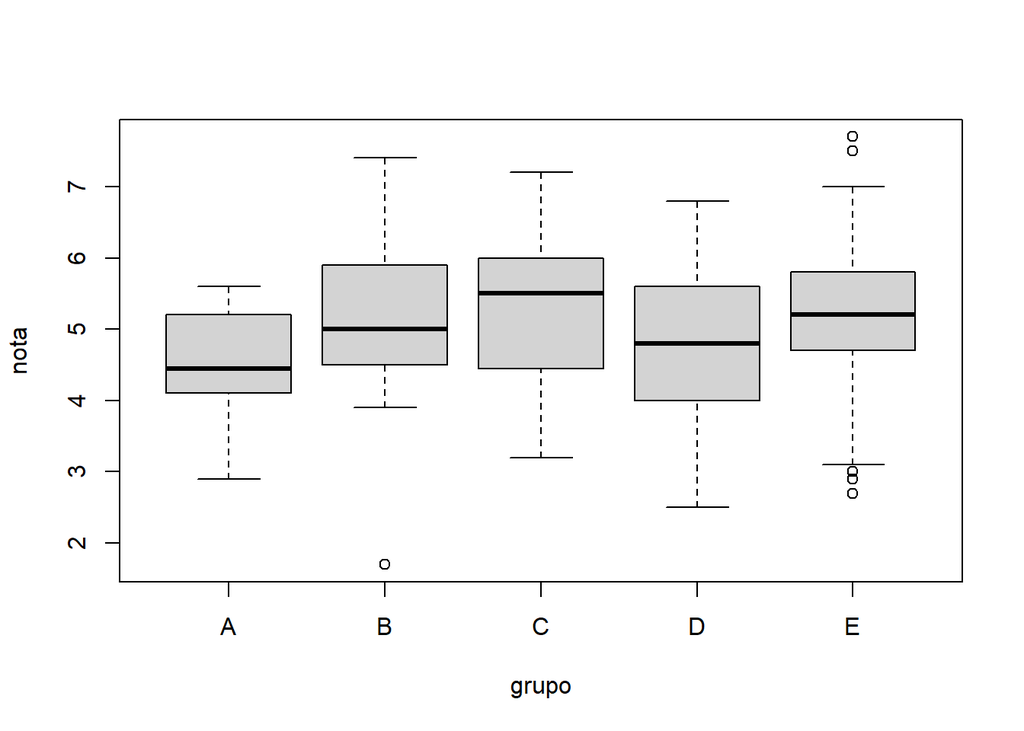

```r
boxplot(dt05$nota ~ dt05$grupo , xlab = "grupo" , ylab = "nota")
```

### 9. Si la variable conc recoge la concentración de plomo (en ppm) en el aire de cierta zona durante un día completo

A. ¿Cuál ha sido la concentración máxima? La concentracion de plomo maximo es:

```r
plomo <- conc

plomo_maxima <- max(plomo)
plomo_maxima
```

```
## [1] 47.34
```

B. ¿En cuántos de los muestreos se ha superado la concentración de 40.0 ppm? La muestras que superna 40ppm

```r
plomo_40 <- (plomo>40)
sum(plomo_40)
```

```
## [1] 61
```

C. ¿Cuál ha sido la concentración media del día?

```r
c_media <- mean(plomo)
c_media
```

```
## [1] 24.07229
```

D. Cuáles fueron las 10 mediciones más bajas del día?

```r
p <- sort(plomo)
p[1:10]
```

```
##  [1] 0.93 1.07 1.77 2.03 2.58 2.73 2.75 2.88 2.88 2.91
```

E. Si la primera medida fue a las 00:00. ¿A qué hora del día se alcanzó la concentración máxima?

```r
 seq(0 , 24 , length = 288)
```

```
##   [1]  0.00000000  0.08362369  0.16724739  0.25087108  0.33449477  0.41811847
##   [7]  0.50174216  0.58536585  0.66898955  0.75261324  0.83623693  0.91986063
##  [13]  1.00348432  1.08710801  1.17073171  1.25435540  1.33797909  1.42160279
##  [19]  1.50522648  1.58885017  1.67247387  1.75609756  1.83972125  1.92334495
##  [25]  2.00696864  2.09059233  2.17421603  2.25783972  2.34146341  2.42508711
##  [31]  2.50871080  2.59233449  2.67595819  2.75958188  2.84320557  2.92682927
##  [37]  3.01045296  3.09407666  3.17770035  3.26132404  3.34494774  3.42857143
##  [43]  3.51219512  3.59581882  3.67944251  3.76306620  3.84668990  3.93031359
##  [49]  4.01393728  4.09756098  4.18118467  4.26480836  4.34843206  4.43205575
##  [55]  4.51567944  4.59930314  4.68292683  4.76655052  4.85017422  4.93379791
##  [61]  5.01742160  5.10104530  5.18466899  5.26829268  5.35191638  5.43554007
##  [67]  5.51916376  5.60278746  5.68641115  5.77003484  5.85365854  5.93728223
##  [73]  6.02090592  6.10452962  6.18815331  6.27177700  6.35540070  6.43902439
##  [79]  6.52264808  6.60627178  6.68989547  6.77351916  6.85714286  6.94076655
##  [85]  7.02439024  7.10801394  7.19163763  7.27526132  7.35888502  7.44250871
```

[output cut: 33 more lines]

```r
length(plomo)
```

```
## [1] 288
```

## 6.2 Parte 2

## 1. Graficar los puntos

```r
x <- 1:10
x
```

```
##  [1]  1  2  3  4  5  6  7  8  9 10
```

```r
y <- (x)^2
  y[3] = 6
  y[4] = 8
y
```

```
##  [1]   1   4   6   8  25  36  49  64  81 100
```

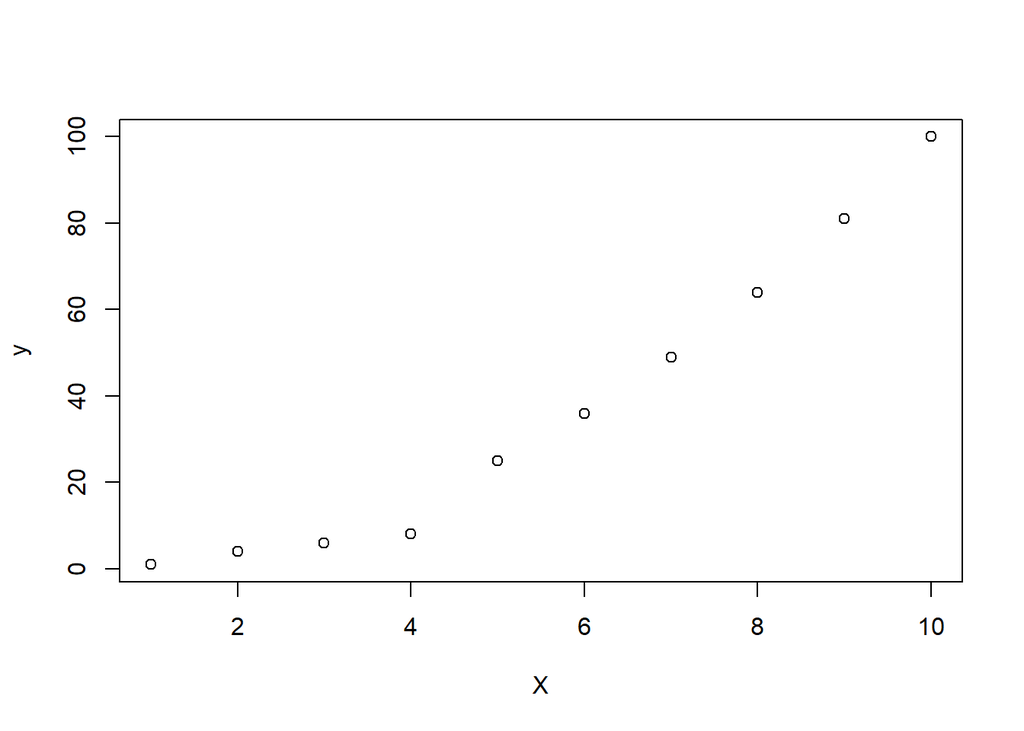

```r
plano <- data.frame(x,y)
plot(x = plano$x , y = plano$y , xlab = "X" , ylab = "y")
```

## 2. Ingresar la matriz A en RStudio A

```r
A <- c(1:4 , 2*(1:4), 3*(1:4) )
matriz_A <- matrix(A ,nrow = 4 , ncol = 3)
matriz_A
```

```
##      [,1] [,2] [,3]
## [1,]    1    2    3
## [2,]    2    4    6
## [3,]    3    6    9
## [4,]    4    8   12
```

## 3.Ingresar la matriz identidad de tamaño 3 I

```r
I <- matrix(0 ,nrow = 3 , ncol = 3)
diag(3)
```

```
##      [,1] [,2] [,3]
## [1,]    1    0    0
## [2,]    0    1    0
## [3,]    0    0    1
```

## 4. Crea una función que cree una matriz nula ingresando las dimensiones

```r
nula <- function(x,y){
  return(matrix(0, nrow = x , ncol = y))
}

nula(5,8)
```

```
##      [,1] [,2] [,3] [,4] [,5] [,6] [,7] [,8]
## [1,]    0    0    0    0    0    0    0    0
## [2,]    0    0    0    0    0    0    0    0
## [3,]    0    0    0    0    0    0    0    0
## [4,]    0    0    0    0    0    0    0    0
## [5,]    0    0    0    0    0    0    0    0
```

## 5. Modificar la matriz diag(4), para que se parezca a la matriz B

```r
b <- matrix(0, nrow = 4 ,ncol = 4)
b <- diag(c(0,2,3,4))
b
```

```
##      [,1] [,2] [,3] [,4]
## [1,]    0    0    0    0
## [2,]    0    2    0    0
## [3,]    0    0    3    0
## [4,]    0    0    0    4
```

## 6. Obtener la matriz transpuesta de A

```r
matriz_At <- t(matriz_A)
matriz_At
```

```
##      [,1] [,2] [,3] [,4]
## [1,]    1    2    3    4
## [2,]    2    4    6    8
## [3,]    3    6    9   12
```

## 7. Realizar las siguientes operaciones

A +B

```r
"A_B <- (matriz_A + b)"
```

```
## [1] "A_B <- (matriz_A + b)"
```

```r
"Error in matriz_A * b : arreglos de dimensón no compatibles"
```

```
## [1] "Error in matriz_A * b : arreglos de dimensón no compatibles"
```

A-B

```r
"AB <- (matriz_A - b)"
```

```
## [1] "AB <- (matriz_A - b)"
```

```r
"Error in matriz_A * b : arreglos de dimensón no compatibles"
```

```
## [1] "Error in matriz_A * b : arreglos de dimensón no compatibles"
```

3B

```r
B_3 <- 3*b
B_3
```

```
##      [,1] [,2] [,3] [,4]
## [1,]    0    0    0    0
## [2,]    0    6    0    0
## [3,]    0    0    9    0
## [4,]    0    0    0   12
```

A*B

```r
"BA <- matriz_A %*% b"
```

```
## [1] "BA <- matriz_A %*% b"
```

```r
"Error in matriz_A * b : arreglos de dimensón no compatibles"
```

```
## [1] "Error in matriz_A * b : arreglos de dimensón no compatibles"
```

## 8. Crea una función para calcular P^6

```r
p <- matrix(c(1,-2,1,2,4,0,3,-2,1), nrow = 3 ,ncol = 3   )
p_6 <- function(x){
  return(p^x)
}
p_6(6)
```

```
##      [,1] [,2] [,3]
## [1,]    1   64  729
## [2,]   64 4096   64
## [3,]    1    0    1
```

## 9. resolver la ecuacion

```r
m <- matrix(c(3,9,3, -1, -2, 1,1,1,-2), nrow = 3, ncol = 3)
e <- t(m)
```

### eigen()

Calcula autovalores y autovectores de matrices numéricas (dobles, enteras, lógicas) o complejas.

```r
eigen(m)
```

```
## eigen() decomposition
## $values
## [1]  1.732051 -1.732051 -1.000000
##
## $vectors
##           [,1]        [,2]          [,3]
## [1,] 0.2955268 -0.08260515  5.441136e-16
## [2,] 0.8363784  0.48159851 -7.071068e-01
## [3,] 0.4616655  0.87249027 -7.071068e-01
```

### det()

calcula el determinante (o su logaritmo) de una matriz

```r
det(m)
```

```
## [1] 3
```

## 11. Considerando las matrices

```r
v <- 1:10
B <- matrix(c(v,2*v,3*v,4*v,5*v), nrow = 10, ncol = 5)
B
```

```
##       [,1] [,2] [,3] [,4] [,5]
##  [1,]    1    2    3    4    5
##  [2,]    2    4    6    8   10
##  [3,]    3    6    9   12   15
##  [4,]    4    8   12   16   20
##  [5,]    5   10   15   20   25
##  [6,]    6   12   18   24   30
##  [7,]    7   14   21   28   35
##  [8,]    8   16   24   32   40
##  [9,]    9   18   27   36   45
## [10,]   10   20   30   40   50
```

```r
A <- matrix(c(0,1,0,0,1,1,0,1,1,0,0,1,0,0,1,1,0,1,0,1,0,1,0,1,0), nrow = 5, ncol = 5)
A
```

```
##      [,1] [,2] [,3] [,4] [,5]
## [1,]    0    1    0    1    0
## [2,]    1    0    1    0    1
## [3,]    0    1    0    1    0
## [4,]    0    1    0    0    1
## [5,]    1    0    1    1    0
```

```r
"resul <- ((A%*%B) - (A%*%t(B)))"
```

```
## [1] "resul <- ((A%*%B) - (A%*%t(B)))"
```

```r
"A Y B NO COMPATIBLES "
```

```
## [1] "A Y B NO COMPATIBLES "
```

## 12. Considere ^β

```r
x <- matrix(c(1,1,1,1,1,1,-1,0,1,2), nrow = 5 , ncol = 2)
x
```

```
##      [,1] [,2]
## [1,]    1    1
## [2,]    1   -1
## [3,]    1    0
## [4,]    1    1
## [5,]    1    2
```

```r
y <- matrix(c(0,0,1,1,3))
y
```

```
##      [,1]
## [1,]    0
## [2,]    0
## [3,]    1
## [4,]    1
## [5,]    3
```

```r
operacion <- ((t(x)%*%x)^(-1))%*%(t(x)%*%y)
operacion
```

```
##          [,1]
## [1,] 3.333333
## [2,] 2.666667
```

## 13.Corre el siguiente código para cargar los vectores “year” y “co2”

```r
data(co2)
means = aggregate(co2, FUN=mean)
year = as.vector(time(means))
co2 = as.vector(means)
```

la diferencia de vector co2 es “d”

```r
library(dplyr)
concen_co2 <- data.frame( año = year , ppm = round(co2,1) )
(concen_co2 <- mutate(concen_co2, d = (concen_co2$ppm[2:39] - concen_co2$ppm[1:39])))
```

```
##     año   ppm     d
## 1  1959 315.8   0.9
## 2  1960 316.7   0.8
## 3  1961 317.5   0.8
## 4  1962 318.3   0.5
## 5  1963 318.8   0.7
## 6  1964 319.5   0.4
## 7  1965 319.9   1.3
## 8  1966 321.2   0.8
## 9  1967 322.0   0.9
## 10 1968 322.9   1.6
## 11 1969 324.5   1.0
## 12 1970 325.5   0.7
## 13 1971 326.2   1.1
## 14 1972 327.3   2.2
```

[output cut: 25 more lines]

```r
plot(x = concen_co2$año[1:38] , y = concen_co2$d[1:38],  main = "CO2",  xlab = "año" , ylab = "diferencais de concetracion co2", font=4 )
```

[output not shown]

```r
concen_co2
```

```
##     año   ppm     d
## 1  1959 315.8   0.9
## 2  1960 316.7   0.8
## 3  1961 317.5   0.8
## 4  1962 318.3   0.5
## 5  1963 318.8   0.7
## 6  1964 319.5   0.4
## 7  1965 319.9   1.3
## 8  1966 321.2   0.8
## 9  1967 322.0   0.9
## 10 1968 322.9   1.6
## 11 1969 324.5   1.0
## 12 1970 325.5   0.7
## 13 1971 326.2   1.1
## 14 1972 327.3   2.2
```

[output cut: 25 more lines]

plot de la diferencia puntos

```r
library(ggplot2)
library(dplyr)
plot(x = concen_co2$año[1:38] , y = concen_co2$d[1:38],  main = "CO2",  xlab = "año" , ylab = "diferencais de concetracion co2", font=4 )
```

[output not shown]

plot de la diferencia linea

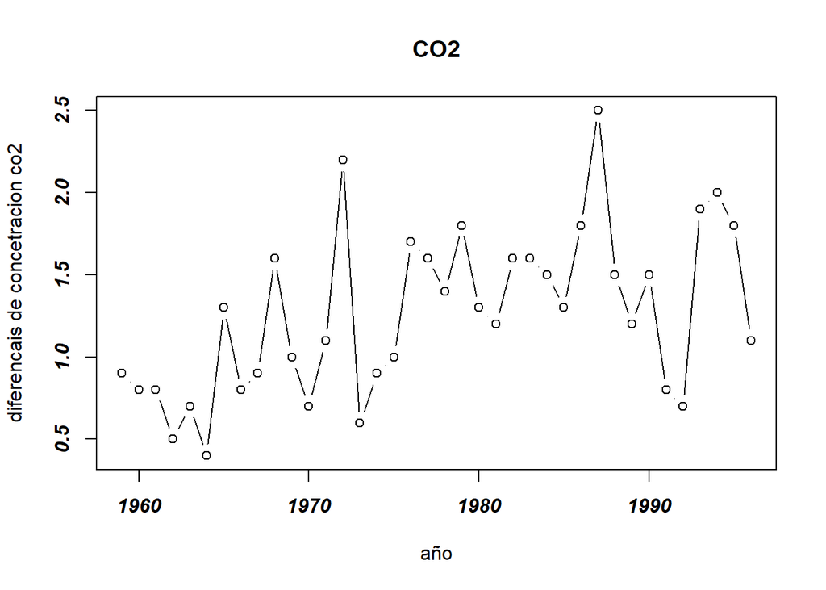

```r
plot( x = concen_co2$año[1:38] , y = concen_co2$d[1:38], , main = "CO2",  xlab = "año" , ylab = "diferencais de concetracion co2" ,type = "b" , font=4 )
```

```r
plot( x = concen_co2$año[1:38] , y = concen_co2$d[1:38], , main = "CO2",  xlab = "año" , ylab = "diferencais de concetracion co2", font=4 )
```

[output not shown]

## 14.

```r
library(readr)
library(tidyverse)
library(dplyr)

(rainfall <- read_csv("rainfall.csv"))
```

```
## # A tibble: 169 x 14
##       num altitude   sep   oct   nov   dec   jan   feb   mar   apr   may name
##     <dbl>    <dbl> <dbl> <dbl> <dbl> <dbl> <dbl> <dbl> <dbl> <dbl> <dbl> <chr>
##  1 110050       30   1.2    33    90   117   135   102    61    20   6.7 Kfar R~
##  2 110351       35   2.3    34    86   121   144   106    62    23   4.5 Saar
##  3 110502       20   2.7    29    89   131   158   109    62    24   3.8 Evron
##  4 111001       10   2.9    32    91   137   152   113    61    21   4.8 Kfar M~
##  5 111650       25   1      27    78   128   136   108    59    21   4.7 Kfar H~
##  6 120202        5   1.5    27    80   127   136    95    49    19   2.7 Haifa ~
##  7 120630      450   1.9    36    93   161   166   128    71    21   4.9 Haifa ~
##  8 120750       30   1.6    31    91   163   170   146    76    22   4.9 Yagur
##  9 120870      210   1.1    32    93   147   147   109    61    16   4.3 Nir Et~
## 10 121051       20   1.8    32    85   147   142   102    56    13   4.5 En Car~
## # ... with 159 more rows, and 2 more variables: x_utm <dbl>, y_utm <dbl>
```

```r
mayor180 <- dplyr::filter(rainfall,sep >= 180 | oct >=180  | nov>=180 | dec>=180 |jan>=180 | feb>=180 | mar>=180 | apr >=180 | may >=180)

mayor180
```

```
## # A tibble: 7 x 14
##       num altitude   sep   oct   nov   dec   jan   feb   mar   apr   may name
##     <dbl>    <dbl> <dbl> <dbl> <dbl> <dbl> <dbl> <dbl> <dbl> <dbl> <dbl> <chr>
## 1 2496029      940   1.9    22    86   159   201   196   115    40   9.1 Golan ~
## 2  210748      300   3.7    36   112   160   201   153    92    34   9.5 Eilon
## 3  210902      600   2.6    35   106   162   205   179   106    35   7.8 Fasutta
## 4  211350      380   2.3    36   115   169   204   160    95    32   9.1 Yehiam
## 5  211415      480   3.2    30   112   170   209   183   105    35   8.3 Kfar M~
## 6  211600      680   2.3    28   100   171   220   192   109    34   7.6 Meron
## 7  212168      825   3.4    37   122   202   238   190   114    38  12.2 Horash~
## # ... with 2 more variables: x_utm <dbl>, y_utm <dbl>
```

### 6.3 parte 3

```r
read_csv("raingaugeDataset.csv")
```

```
## # A tibble: 12,419 x 22
##    date       qc00000132 qc00000135 qc00000207 qc00000208 qc00000211 qc00000219
##    <chr>           <dbl>      <dbl>      <dbl>      <dbl>      <dbl>      <dbl>
##  1 1/01/1980         0          0            0          0        0          5
##  2 2/01/1980         0          0            0          0        5.6        0
##  3 3/01/1980         0          0            0          0        0.8        0.3
##  4 4/01/1980         0.8        0.2          0          0        0          4
##  5 5/01/1980         0          0            0          0        0          4
##  6 6/01/1980         0          0            0          0        0          0
##  7 7/01/1980         0          0            0          0        0          0
##  8 8/01/1980         0          0            0          0        0          0
##  9 9/01/1980         0          0            0          0        0          2
## 10 10/01/1980        0          0            0          0        0          0
## # ... with 12,409 more rows, and 15 more variables: qc00000230 <dbl>,
## #   qc00000231 <dbl>, qc00000235 <dbl>, qc00000237 <dbl>, qc00000238 <dbl>,
## #   qc00000240 <dbl>, qc00000241 <dbl>, qc00000247 <dbl>, qc00000248 <dbl>,
## #   qc00000250 <dbl>, qc00000255 <dbl>, qc00000278 <dbl>, qc00000281 <dbl>,
## #   qc00000301 <dbl>, qc00000304 <dbl>
```

```r
pp_diaria <- read_csv("raingaugeDataset.csv")
lista <- read_csv("listRaingauge.csv")
c_tabaconas <- dplyr::filter(lista , NOM_EST == "TABACONAS")
```

EL CODIGO DE TABACONAS ES : qc00000240

```r
library(dplyr)
dato_pp <- pp_diaria %>% select(date, qc00000240) %>% mutate(date = as.Date( date , format = "%d/%m/%Y")) %>% rename(pp = qc00000240) %>% arrange(date)


seq(as.Date("1980-01-01"), as.Date("2013-12-31"), by = "day") %>% length()
```

```
## [1] 12419
```

```r
tail(dato_pp)
```

```
## # A tibble: 6 x 2
##   date          pp
##   <date>     <dbl>
## 1 2013-12-26   6
## 2 2013-12-27   3.5
## 3 2013-12-28   2.4
## 4 2013-12-29   5.3
## 5 2013-12-30  11.8
## 6 2013-12-31   2.6
```

precipitacion mensual

```r
library(dplyr)
library(tidyverse)
pp_mensual <- dato_pp %>% group_by(date = str_sub(date,1,7)) %>%
  mutate(missival = sum(is.na(pp)) * 100 /n() ) %>% summarize( pp = sum(pp, na.rm =T ), missival = unique(missival))

pp_mensua_ano <- pp_mensual %>% mutate(pp = ifelse(missival >= 10, NA , pp))
```

A. missing values :

```r
 sum(is.na(pp_mensual$pp))
```

```
## [1] 0
```

B. MISSING VALUES >10%

```r
pp_mensual
```

```
## # A tibble: 408 x 3
##    date       pp missival
##    <chr>   <dbl>    <dbl>
##  1 1980-01  87.9        0
##  2 1980-02  48.3        0
##  3 1980-03 128.         0
##  4 1980-04  44.3        0
##  5 1980-05  40          0
##  6 1980-06  93.5        0
##  7 1980-07  33.6        0
##  8 1980-08  13          0
##  9 1980-09  13.2        0
## 10 1980-10 130.         0
## # ... with 398 more rows
```

C. MISSING VALUES MENSUAL

```r
sum(is.na(pp_mensua_ano$pp))
```

```
## [1] 11
```

D. FUNCION PARA CALCULAR DATOS DE PRECIPITACION MENSUAL

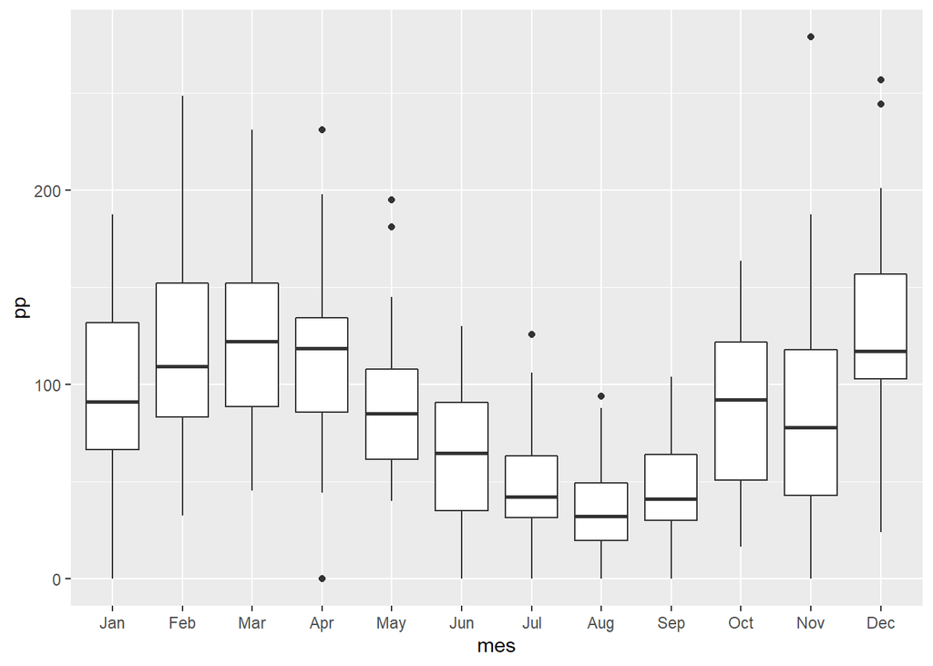

```r
library(dplyr)
p_1980_2013 <- dplyr::filter(pp_mensual, date >="1980-01" & date <= "2013-12")%>% mutate(mes = str_sub(date,6,7))

library(ggplot2)
ggplot(p_1980_2013, aes(mes ,pp)) + geom_boxplot() + scale_x_discrete(label = month.abb)
```